# Part 0: Validation of Matrix-Based OLS and HC Estimators

Quantitative Methods

2026-02-16

# 1 1. Purpose

The purpose of this document is to rigorously validate the fast, matrix-based implementation of Ordinary Least Squares (OLS) and Heteroskedasticity-Consistent (HC) covariance estimators used in this project.

**Scope**: * This document validates the **implementation** of OLS and HC1–HC3. * It does NOT study coverage or $S_{\text{Inf}}$ behavior; those are addressed in `01_null_calibration.Rmd` and subsequent notebooks.

**Motivation**: Later notebooks use a high-performance matrix engine instead of repeatedly calling `lm()` and `vcovHC()`. We must verify that this engine is **algebraically correct** and **numerically indistinguishable** from the well-vetted R implementations (`stats::lm`, `sandwich::vcovHC`).

**Reproducibility and Tolerances**: * All simulations use a fixed global random seed (2024) set once in `R/00_config.R` and inherited by this notebook via `source("R/00_config.R")`. * When we compare numerical implementations, differences on the order of $10^{-10}$ or smaller are treated as negligible, consistent with double-precision floating-point rounding error.

# 2 2. Theoretical Equivalence

## 2.1 2.1 OLS Estimator

For a linear regression model $y = X\beta + \varepsilon$, where $y$ is an $n \times 1$ vector, $X$ is an $n \times k$ design matrix (including a column of ones for the intercept), and $\beta$ is a $k \times 1$ coefficient vector, the OLS estimator is:

$$\hat{\beta} = (X'X)^{-1} X'y$$

The residuals are $\hat{u} = y - X\hat{\beta}$. The classic homoskedastic covariance matrix is:

$$\widehat{\text{Var}}_{\text{OLS}}(\hat{\beta}) = \hat{\sigma}^2
(X'X)^{-1}, \quad \text{where } \hat{\sigma}^2 = \frac{\sum
\hat{u}_i^2}{n - k}$$

These are the standard least-squares formulas; see, for example, Greene (2012, Ch. 3).

## 2.2 2.2 HC Estimators (Sandwich Form)

The Heteroskedasticity-Consistent covariance matrix takes the “sandwich” form (White, 1980):

$$\widehat{\text{Var}}_{\text{HC}}(\hat{\beta}) = (X'X)^{-1} X'
\hat{\Omega} X (X'X)^{-1}$$

where $\hat{\Omega} = \text{diag}(\omega_1, \dots, \omega_n)$ is a diagonal matrix of weighted squared residuals. The weights $\omega_i$ differ by HC type (MacKinnon & White, 1985; Long & Ervin, 2000):

- **HC0**: $\omega_i = \hat{u}_i^2$
- **HC1**: $\omega_i = \frac{n}{n-k} \hat{u}_i^2$ (Degrees of freedom adjustment)
- **HC2**: $\omega_i = \frac{\hat{u}_i^2}{1 - h_{ii}}$ (Leverage adjustment)
- **HC3**: $\omega_i = \frac{\hat{u}_i^2}{(1 - h_{ii})^2}$ (Jackknife approximation)

Here, $h_{ii}$ are the diagonal elements of the hat matrix $H = X(X'X)^{-1}X'$.

**Note**: For HC2 and HC3 we divide by $(1 - h_{ii})$ and $(1 - h_{ii})^2$. Under standard OLS assumptions with an intercept and $n > k$, all leverages satisfy $0 < h_{ii} < 1$, so these denominators are well-defined. If the design is rank-deficient, our core solver will stop with an error.

## 2.3 2.3 Matrix Implementation

Our fast implementation (`fit_ols_hc` in `R/10_dgp_and_fits.R`) computes these quantities directly using optimized linear algebra:

- $(X'X)^{-1}$ $\to$ `XtX_inv <- chol2inv(chol(crossprod(X)))` (Cholesky decomposition).
- $\hat{\beta}$ $\to$ `beta <- backsolve(R, forwardsolve(t(R), crossprod(X, y)))`.
- Residuals $\hat{u}$ $\to$ `resid <- y - X %*% beta`.
- Leverages $h_{ii}$ $\to$ `h <- rowSums((X %*% XtX_inv) * X)`.
- $\hat{\Omega}$ via $\omega_i$ $\to$ implemented via `X_weighted <- X * sqrt(u_sq)`; `meat <- crossprod(X_weighted)` ($= X' \hat{\Omega} X$).

This approach avoids the overhead of creating S3 objects and method dispatch, providing significant speedups while maintaining algebraic exactness.

# 3 3. Numerical Validation Design

We define a grid of scenarios to stress-test the implementation across different sample sizes, dimensions, and data generating processes (DGPs).

## 3.1 3.1 Scenarios

- **Sample Sizes ($N$)**: 20, 50, 100, 1000.
- **Regressors ($p$)**: 1 (Simple Regression), 4 (Multiple Regression).
- **DGPs**:
  1. **Homoskedastic**:
     - $X_j \sim N(0, 1)$ independently for $j=1,\dots,p$.
     - $y = 1 + X\beta + \varepsilon$, with $\beta_j = 1$ and $\varepsilon \sim N(0, 1)$.
  2. **Heteroskedastic**:
     - Same $X$.
     - $\varepsilon_i \sim N(0, \sigma_i^2)$, with
       $$\sigma_i = 1 + 0.5 X_{1,i}^2.$$
  3. **Collinear** (only when $p > 1$):
     - Draw $X_1 \sim N(0, 1)$.
     - Set $X_2 = X_1 + \eta$ with $\eta \sim N(0, 0.01^2)$ to introduce near-collinearity.

## 3.2 3.2 Validation Logic

For each simulation and scenario, we validate: 1. **OLS point estimates** $\hat{\beta}$. 2. **Classic homoskedastic SEs** via `vcov()`. 3. **HC1–HC3 robust SEs** via `vcovHC()`.

**Procedure**: 1. Generate data $(y, X)$. 2. **Reference**: Fit using `lm()`, compute SEs using `vcov()` and `sandwich::vcovHC()`. 3. **Manual**: Compute $\hat{\beta}$ and SEs using the project’s core matrix implementation `fit_ols_hc()`. * *Note*: For $p=1$, we also cross-check the helper `fit_ols_get_hc_ci()` to ensure it wraps the core engine correctly. 4. Compute **Absolute Difference** ($|Est_{ref} - Est_{man}|$) and **Relative Difference** ($|Est_{ref} - Est_{man}| / |Est_{ref}|$).

# 4 4. Numerical Results

We summarize the maximum absolute and relative differences observed across all simulations.

## 4.1 4.1 Summary by Metric

The table below shows the **worst-case** discrepancies encountered across all scenarios (N, p, DGP).

```r
summary_table <- validation_dt[, .(
  Max_Abs_Diff = max(max_abs_diff),
  Max_Rel_Diff = max(max_rel_diff)
), by = metric]

kable(summary_table, digits = 20, caption = "Maximum Differences: Manual vs Reference Implementation")
```

Maximum Differences: Manual vs Reference Implementation

| metric | Max_Abs_Diff | Max_Rel_Diff |
| --- | --- | --- |
| Beta | 1.914813e-09 | 9.535719e-10 |
| SE_Classic | 1.473119e-09 | 2.994351e-11 |
| SE_HC1 | 1.557481e-09 | 4.322394e-11 |
| SE_HC2 | 2.513097e-09 | 6.185433e-11 |
| SE_HC3 | 2.522043e-09 | 4.884647e-11 |

## 4.2 4.2 Distribution of Errors

We visualize the distribution of relative errors (log10 scale) to confirm that the vast majority of discrepancies are at machine precision ($\approx 10^{-16}$).

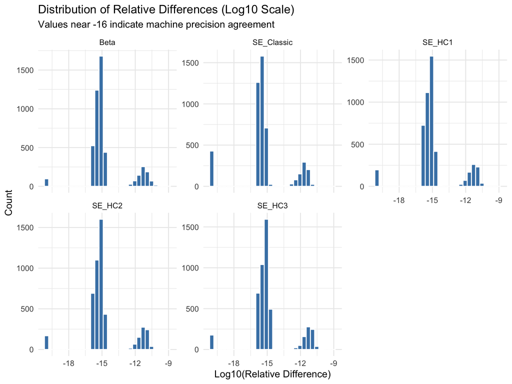

```r
ggplot(validation_dt, aes(x = log10(max_rel_diff + 1e-20))) +
  geom_histogram(bins = 30, fill = "steelblue", color = "white") +
  facet_wrap(~ metric, scales = "free_y") +
  labs(
    title = "Distribution of Relative Differences (Log10 Scale)",
    subtitle = "Values near -16 indicate machine precision agreement",
    x = "Log10(Relative Difference)",
    y = "Count"
  ) +
  theme_minimal()
```

# 5 5. Conclusion

## 5.1 5.1 Theoretical Verification

The matrix implementation directly follows the standard OLS and HC1–HC3 sandwich formulas (White, 1980; MacKinnon and White, 1985; Long and Ervin, 2000).

## 5.3 5.3 OLS Verification

Manual OLS coefficients and classic covariance match `lm()` and `vcov()` to within machine precision.

**Implication**: The matrix engine is a numerically equivalent drop-in replacement for `lm()` + `vcov()`/`vcovHC()`. This validates its use in the large-scale simulations and calibration steps that follow.